# What we sing when we sing rap songs

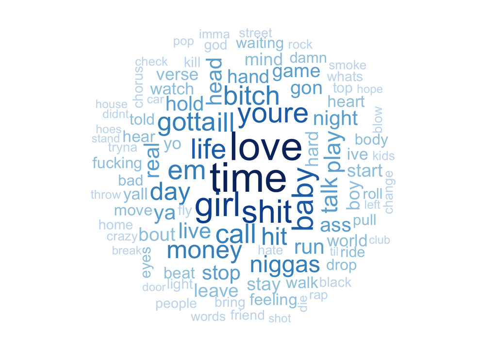

```r
word_counts_wc =data.frame(word_counts_10s %>% count(word,sort = T) )
wordcloud(word_counts_wc$word,word_counts_wc$n,
          max.words=100,scale=c(3.5,0.1),
         min.freq=3,
          random.order=FALSE,
          random.color=FALSE,
          colors=brewer.pal(9,"Blues"))
```

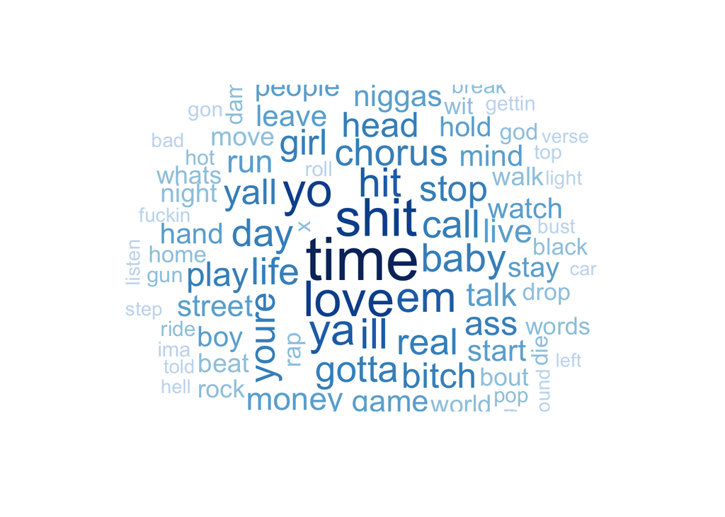

```r
word_counts_wc2 =data.frame(word_counts_00s %>% count(word,sort = T) )
wordcloud(word_counts_wc2$word,word_counts_wc2$n,
          max.words=100,scale=c(3.5,0.08),
         min.freq=3,
          random.order=FALSE,
          random.color=FALSE,
          colors=brewer.pal(9,"Blues"))
```

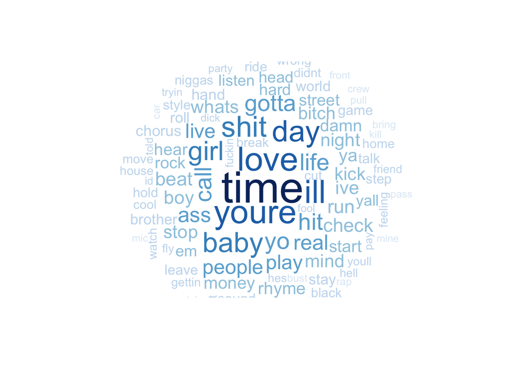

```r
word_counts_wc3 =data.frame(word_counts_90s %>% count(word,sort = T) )
wordcloud(word_counts_wc3$word,word_counts_wc3$n,
          max.words=100,scale=c(3.5,0.1),
         min.freq=3,
          random.order=FALSE,
          random.color=FALSE,
          colors=brewer.pal(9,"Blues"))
```

The top 15 popular words list doesn’t vary too much over 3 decades. Despite the fact that there’re all some negative words pop up in the list among all 3 three decades, the lyrics in recent two decades tend to include more profanity and racially charged words. From the word frequency plot, it is not hard to see that word ‘time’ and ‘love’ appear among all songs in each decade.

But let’s take a closer to the list and see how the usage of word changes over time.

##### Popularity of Most Common Words

Since the data doesn’t include songs realsed in recent 3 years, so I decide to use the ratio of occurrence of a word in a decade to total number of songs in that decade and compared ratios to find this word’s usage trend.

```r
top_words = c(inner_join(word_counts_10s_top15,word_counts_00s_top15, by='word' ) %>% inner_join(., word_counts_90s_top15, by='word')) $word

df1 = word_counts_90s_top15 %>% filter(word %in%  top_words )%>% mutate(time = '1990s')
df2 = word_counts_00s_top15 %>% filter(word %in%  top_words )%>% mutate(time = '2000s')
df3 = word_counts_10s_top15 %>% filter(word %in%  top_words )%>% mutate(time = '2010s')
df_top_cnts = rbind(df1,df2,df3)

cbnd_df = left_join(df_top_cnts, song_num_by_decade%>% filter(time %in% c("1990s","2000s","2010s")),by = "time")
cbnd_df_ratio = cbnd_df %>% mutate(ratio = n/Count) %>% select(word, ratio, time)
```

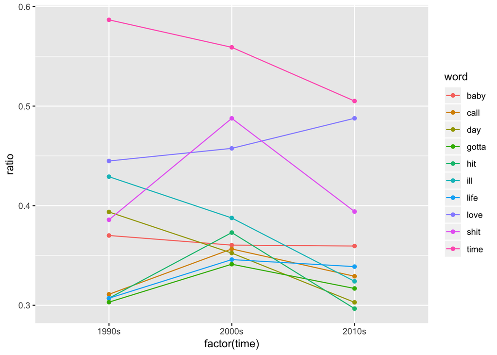

```r
p = ggplot(data = cbnd_df_ratio , aes(x = factor(time), y = ratio, group=word, color = word))  +  geom_line() +  geom_point()
p
```

```r
bing_pos <- get_sentiments("bing") %>%
  filter(sentiment == "positive" )

dt = tidy_lyrics  %>%
  inner_join(get_sentiments("bing"), by ='word')  %>%  group_by(id,sentiment) %>%
  summarise(Cnt = n())

dt1 = dt %>% spread(sentiment, value = Cnt) %>% mutate(score = positive -negative )
song_name  = tidy_lyrics %>% select(id, song) %>% distinct()
dt2 = dt1  %>% inner_join(song_name , by ='id')  %>%  select(song, score )
```

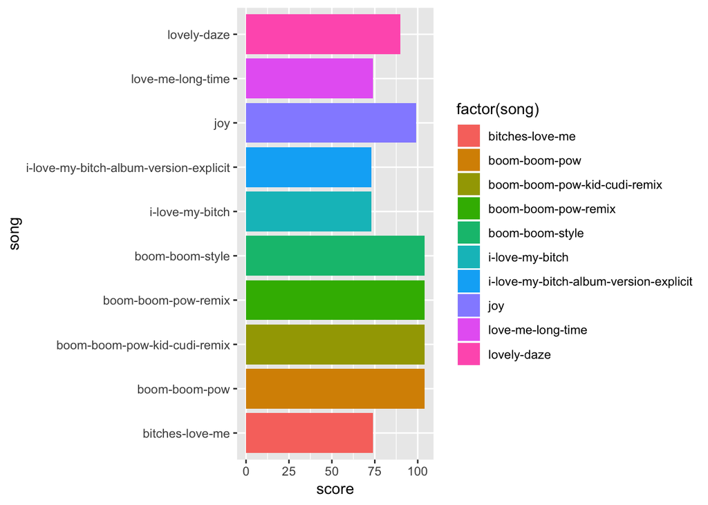

```r
dt2_top10 = dt2%>% arrange(desc(score)) %>% head(10)

dt2_end10  = dt2%>% arrange(desc(score)) %>% filter(is.na(score) == F) %>% tail(10)

p1 = ggplot(dt2_top10, aes(x= song, y= score, fill = factor(song))) + geom_bar(stat = 'identity') + coord_flip()

p2= ggplot(dt2_end10, aes(x= song, y= score, fill = factor(song))) + geom_bar(stat = 'identity') + coord_flip()

p1
```

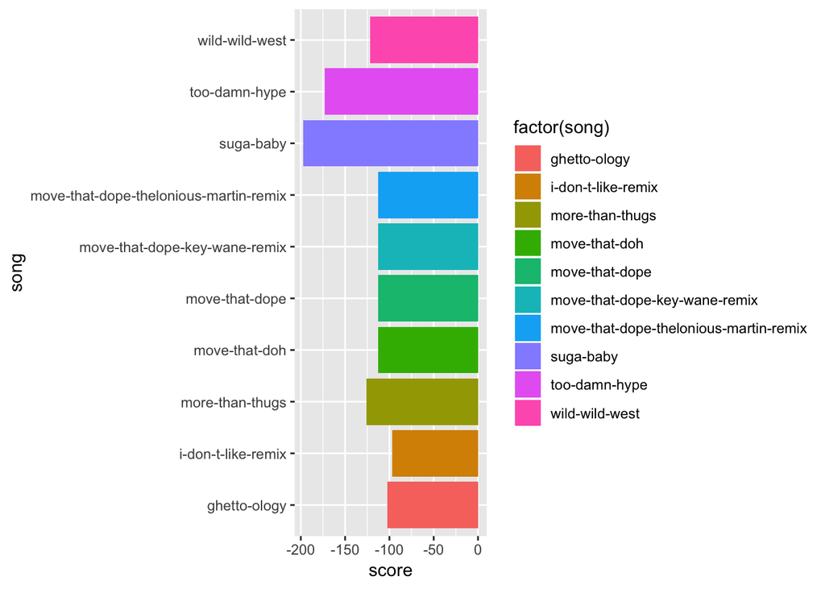

```r
p2
```

From the plot, I plot song by total sentiment score and it can be used as a guide for radio station to decide which song to play in public in day time.